# Quiz: Diamonds

### Boxplots by Clarity

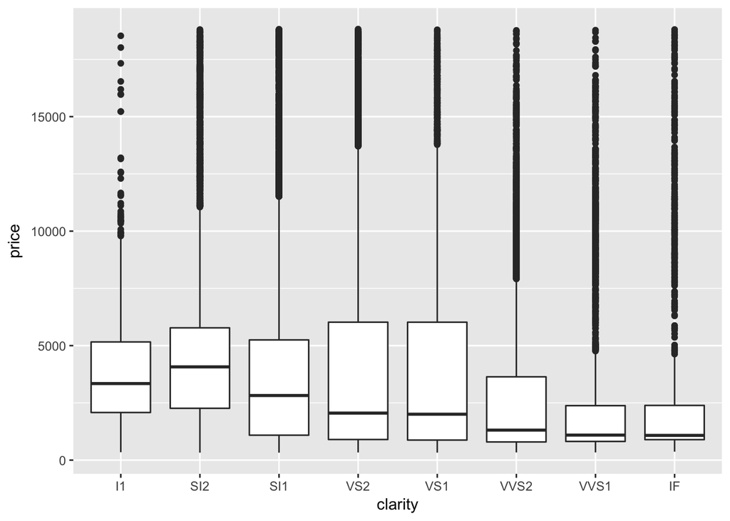

```r
ggplot(data = diamonds, aes(x = clarity, y = price)) +
  geom_boxplot()
```

```r
#coord_cartesian(ylim=c(0, 7000))
```

### Boxplots by Color

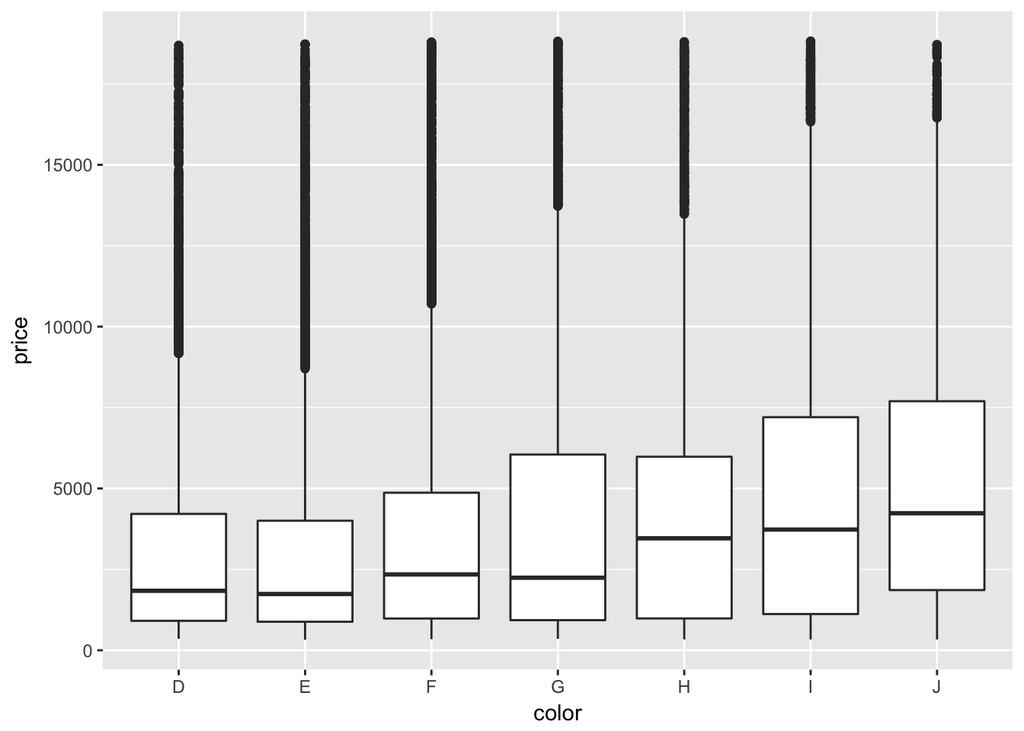

```r
ggplot(data = diamonds, aes(x = color, y = price)) +
  geom_boxplot()
```

```r
#coord_cartesian(ylim = c(0, 8000))
```

Oddities observed:

More expensive ones are the ones that aren’t ideal in quality. For example, color J diamonds are more expensive than colorless diamonds.

## Interquartile range - IQR

1. What is the price range for the middle 50% of diamonds with color D?

```r
by(diamonds$price, diamonds$color, summary)
```

```
## diamonds$color: D
##    Min. 1st Qu.  Median    Mean 3rd Qu.    Max.
##     357     911    1838    3170    4214   18690
## --------------------------------------------------------
## diamonds$color: E
##    Min. 1st Qu.  Median    Mean 3rd Qu.    Max.
##     326     882    1739    3077    4003   18730
## --------------------------------------------------------
## diamonds$color: F
##    Min. 1st Qu.  Median    Mean 3rd Qu.    Max.
##     342     982    2344    3725    4868   18790
## --------------------------------------------------------
## diamonds$color: G
##    Min. 1st Qu.  Median    Mean 3rd Qu.    Max.
##     354     931    2242    3999    6048   18820
## --------------------------------------------------------
## diamonds$color: H
##    Min. 1st Qu.  Median    Mean 3rd Qu.    Max.
##     337     984    3460    4487    5980   18800
## --------------------------------------------------------
## diamonds$color: I
##    Min. 1st Qu.  Median    Mean 3rd Qu.    Max.
##     334    1120    3730    5092    7202   18820
## --------------------------------------------------------
## diamonds$color: J
##    Min. 1st Qu.  Median    Mean 3rd Qu.    Max.
##     335    1860    4234    5324    7695   18710
```

first quartile (25%) $911 third quartile (75%) $4214

2. What is the price range for the middle 50% of diamonds with color J?

first quartile (25%) $1860 third quartile (75%) $7695

3. What is the IQR for diamonds with the best color?

```r
IQR(subset(diamonds, color == 'D')$price)
```

```
## [1] 3302.5
```

4. What is the IQR for diamonds with the worst color?

```r
IQR(subset(diamonds, color == 'J')$price)
```

```
## [1] 5834.5
```

## Price per Carat Box Plots by Color

Investigate the price per carat of diamonds across the different colors of diamonds using boxplots.

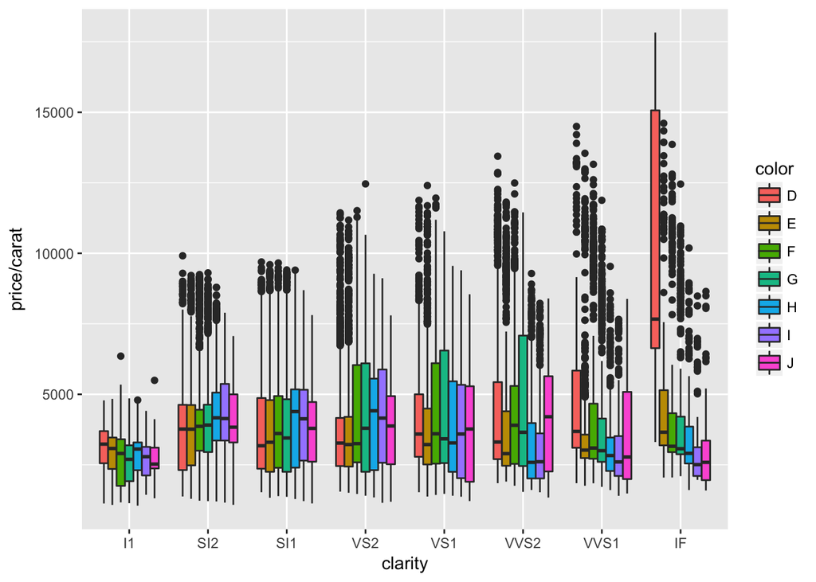

```r
qplot(y=price/carat, x=clarity, data=subset(diamonds, !is.na(price)), fill=color, geom="boxplot")
```

https://discussions.udacity.com/t/price-boxplots-by-color/119304/26?u=alona_11249598748233

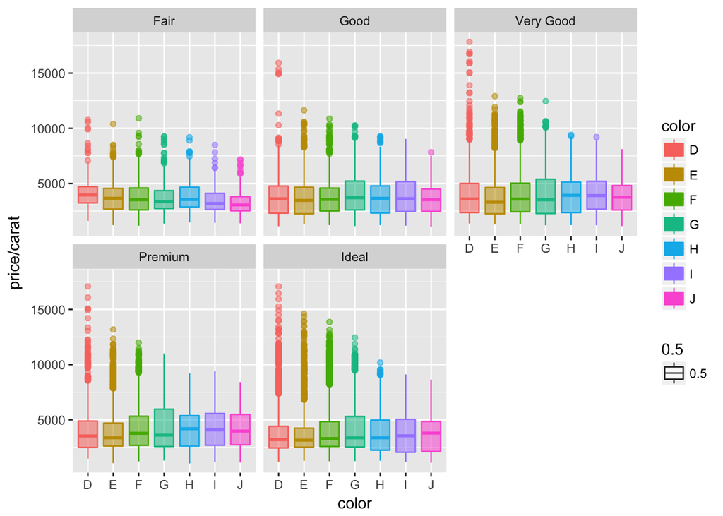

```r
qplot(x = color, y=price / carat , data = diamonds, geom='boxplot', color = color, fill= color, alpha=.5) + facet_wrap(~cut)
```

(https://discussions.udacity.com/t/problem-set-3-price-per-carat-box-plots-by-color/28325/11?u=alona_11249598748233)

My solution:

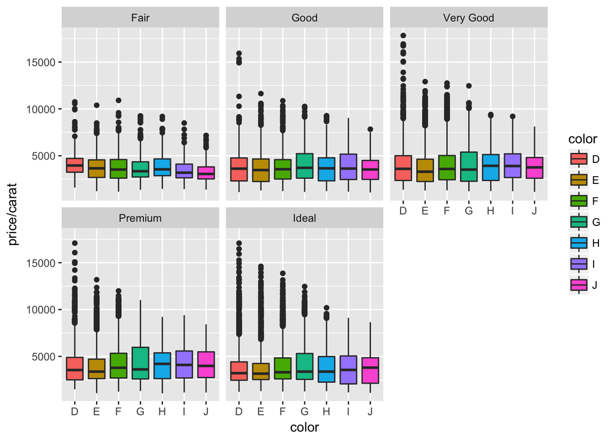

```r
ggplot(data = diamonds, aes(x=color, y = price / carat, fill = color)) +
  geom_boxplot() +
  facet_wrap(~cut)
```